# Exploration of Covid-19 and covariates data

Marina Espinasse

2023-03-30

# 1 Libraries

```r
library(tidyverse)
library(readxl)
library(here)
library(kableExtra)
library(DT)
library(rebus)
```

# 2 Loading the datasets

Here I will explore the datasets for the thesis: Covid-19 cases registered in each municipality of Belgium, administered vaccines, and the covariates data (N02, 03,PM10, PM2.5, BC)

Data for Covid-19 were downloaded [here](https://epistat.sciensano.be/covid/) and includes two datasets. The codebook for the data sets is located [here](https://epistat.sciensano.be/COVID19BE_codebook.pdf)

1. Confirmed cases by date and municipality
2. Administered vaccines by week, municipality, age and dose

# 3 Exploring the datasets

## 3.1 Covid19 cases per municipality dataset

```r
cases <- read.csv(here("data", "COVID19BE_CASES_MUNI.csv"))
```

Cases dataset has the following columns: date (of the first symptoms, 2020-2023), NIS municipality code, Dutch and French municipalities’ names, Administrative district name in Dutch and French, Belgian Province, Belgian Region, and the number of confirmed cases

Let’s first have a quick look at the dataset:

```r
glimpse(cases)
```

```
## Rows: 419,412
## Columns: 9
## $ NIS5                 <int> NA, NA, NA, NA, NA, NA, NA, NA, NA, NA, NA, NA, N…
## $ DATE                 <chr> "2020-03-04", "2020-03-06", "2020-03-08", "2020-0…
## $ TX_DESCR_NL          <chr> NA, NA, NA, NA, NA, NA, NA, NA, NA, NA, NA, NA, N…
## $ TX_DESCR_FR          <chr> NA, NA, NA, NA, NA, NA, NA, NA, NA, NA, NA, NA, N…
## $ TX_ADM_DSTR_DESCR_NL <chr> NA, NA, NA, NA, NA, NA, NA, NA, NA, NA, NA, NA, N…
## $ TX_ADM_DSTR_DESCR_FR <chr> NA, NA, NA, NA, NA, NA, NA, NA, NA, NA, NA, NA, N…
## $ PROVINCE             <chr> NA, NA, NA, NA, NA, NA, NA, NA, NA, NA, NA, NA, N…
## $ REGION               <chr> NA, NA, NA, NA, NA, NA, NA, NA, NA, NA, NA, NA, N…
## $ CASES                <chr> "6", "<5", "<5", "<5", "7", "<5", "5", "19", "7",…
```

How many missing data points in each column?

```r
map(cases, ~ sum(is.na(.x)))
```

```
## $NIS5
## [1] 1071
##
## $DATE
## [1] 0
##
## $TX_DESCR_NL
## [1] 1071
##
## $TX_DESCR_FR
## [1] 1071
##
## $TX_ADM_DSTR_DESCR_NL
## [1] 1071
##
## $TX_ADM_DSTR_DESCR_FR
## [1] 1071
##
## $PROVINCE
## [1] 1071
##
## $REGION
## [1] 1071
##
## $CASES
## [1] 0
```

There are 1071 row of data (including all years 2020-2023 and most of the moths), where there is no information on municipality. Can we just remove these rows?

How many of such observations without municipality information were in 2021?

```r
test <- cases |> filter(str_detect(DATE, "2021."))
map(test, ~ sum(is.na(.x)))#365
```

```
## $NIS5
## [1] 365
##
## $DATE
## [1] 0
##
## $TX_DESCR_NL
## [1] 365
##
## $TX_DESCR_FR
## [1] 365
##
## $TX_ADM_DSTR_DESCR_NL
## [1] 365
##
## $TX_ADM_DSTR_DESCR_FR
## [1] 365
##
## $PROVINCE
## [1] 365
##
## $REGION
## [1] 365
##
## $CASES
## [1] 0
```

**Exploring the data without missing information: cases per municipality**

I will remove unnecessary columns and rename some. I also separate date into year, month and day

```r
cases_prep <- cases |>
  filter(!is.na(NIS5)) |>
  select(c(NIS5, DATE, PROVINCE, REGION, CASES)) |>
  rename(mcp_code = NIS5,
         date = DATE,
         province = PROVINCE,
         region = REGION,
         cases = CASES) |>
  mutate(year = lubridate::year(date),
         month = lubridate::month(date),
         day = lubridate::day(date)
         )
```

```r
#create a summary table with year, month and mean, max and min cases per month. But first change <5 to 5 to make the column numerical.

cases_summary <- cases_prep |>
  mutate(cases = ifelse(cases == "<5", 5, cases)) |>
  mutate(cases = as.numeric(cases)) |>
  group_by(mcp_code, year, month) |>
  summarize(min = min(cases),
            max=max(cases),
            mean = mean(cases))

#the distribution of the mean cases count per municipality
mosaic::fav_stats(cases_summary$mean)
```

```
##  min Q1 median   Q3      max     mean       sd     n missing
##    5  5   5.25 7.75 1675.774 10.27399 23.43787 20563       0
```

**How many records are made per municipality?**

```r
library(gt)
```

```r
mcp_summary_months <- cases_prep |>
  group_by(mcp_code, year) |>
  summarise(n_month = n_distinct(month))


#kable(mcp_summary_months, "html") %>% kable_styling("striped") %>% scroll_box(width = "100%")
#
datatable(mcp_summary_months)
```

|  | mcp_code | year | n_month |
| --- | --- | --- | --- |
| 1 | 11001 | 2020 | 10 |
| 2 | 11001 | 2021 | 12 |
| 3 | 11001 | 2022 | 12 |
| 4 | 11001 | 2023 | 2 |
| 5 | 11002 | 2020 | 10 |
| 6 | 11002 | 2021 | 12 |
| 7 | 11002 | 2022 | 12 |
| 8 | 11002 | 2023 | 2 |
| 9 | 11004 | 2020 | 10 |
| 10 | 11004 | 2021 | 12 |

[output cut: 2313 more lines]

In some municipalities, for instance, Limburg 2021 (73028), cases were registered not every month but only in April, October, November, December. What would be the best way to aggregate counts per week then?

```r
mcp_summary_days <- cases_prep |>
  group_by(mcp_code, year, month) |>
  summarise(n_days = n_distinct(day))


datatable(mcp_summary_days)
```

|  | mcp_code | year | month | n_days |
| --- | --- | --- | --- | --- |
| 1 | 11001 | 2020 | 3 | 9 |
| 2 | 11001 | 2020 | 4 | 20 |
| 3 | 11001 | 2020 | 5 | 7 |
| 4 | 11001 | 2020 | 6 | 2 |
| 5 | 11001 | 2020 | 7 | 10 |
| 6 | 11001 | 2020 | 8 | 14 |
| 7 | 11001 | 2020 | 9 | 23 |
| 8 | 11001 | 2020 | 10 | 29 |
| 9 | 11001 | 2020 | 11 | 24 |
| 10 | 11001 | 2020 | 12 | 20 |

[output cut: 20553 more lines]

Similarly, there will not be registrations of COVID19 every day, in some municipalities and months (like 11004 in June 2020), only 1 record was made. I will compare how Lowe et al. had their dengue data, it is possible they had the same problem.

### 3.1.1 Distribution of <5 values in the COVID19 dataset

How many <5 values are there in total?

```r
cases_prep |>
  filter(cases == "<5") |>
  nrow()
```

```
## [1] 230954
```

230954 out of 418341, which is 55%.

How many times per month (regardless of a municipality), we observe <5 values in the data set? Here, I will look at 2021 year only

**Data for 2021**: there are 153308 observations in total.

```r
bias_monthly <- cases_prep |>
  filter(year == "2021") |>
  group_by(month) |>
    summarize(bias_count = count(cases == "<5"))

breaks1 <- seq(1, 12, by=1)
breaks1y <-seq(2500, 9000, by = 2000)

bias_monthly
```

```
## # A tibble: 12 × 2
##    month bias_count
##    <dbl>      <int>
##  1     1       8618
##  2     2       7866
##  3     3       7914
##  4     4       8063
##  5     5       8499
##  6     6       5576
##  7     7       7835
##  8     8       8328
##  9     9       7890
## 10    10       7038
## 11    11       2674
## 12    12       3784
```

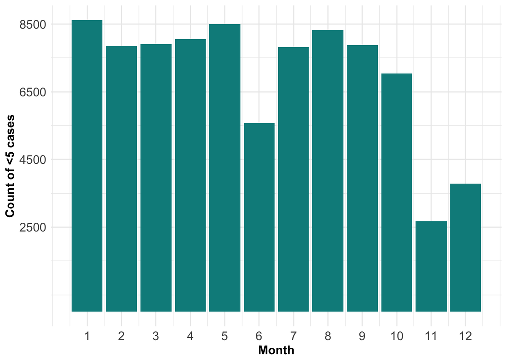

```r
plot1 <- ggplot(data = bias_monthly, aes(x = month, y = bias_count)) +
  geom_col(fill = "darkcyan") +
  scale_x_continuous(breaks = breaks1) +
  scale_y_continuous(breaks = breaks1y) +
  theme_minimal() +
  theme(axis.text = element_text(size = 12),
        axis.title = element_text(size = 12, vjust = +3, face = "bold")) +
  labs(x = "Month", y = "Count of <5 cases")

plot1
```

Save this figure

```r
ggsave(plot = plot1, filename = "./figs/count_less_than5_cases.pdf",
       dpi = 250, width = 7, height=5)
```

Only at the end of 2021 the count of <5 was small, but all other months - about the same (except in June 2021).

But what is the proportion of <5 counts per month, dose it differ between months?

```r
bias_proportion <- cases_prep |>
  filter(year == "2021") |>
  group_by(month) |>
    summarize(bias_count = count(cases == "<5"),
              total = n(),
              bias_prop = bias_count/total)

kable(bias_proportion) |> kable_paper("hover", full_width = F)
```

| month | bias_count | total | bias_prop |
| --- | --- | --- | --- |
| 1 | 8618 | 12226 | 0.7048912 |
| 2 | 7866 | 11495 | 0.6842975 |
| 3 | 7914 | 14735 | 0.5370886 |
| 4 | 8063 | 14435 | 0.5585729 |
| 5 | 8499 | 12832 | 0.6623286 |
| 6 | 5576 | 6512 | 0.8562654 |
| 7 | 7835 | 10093 | 0.7762806 |
| 8 | 8328 | 11309 | 0.7364046 |
| 9 | 7890 | 11037 | 0.7148682 |
| 10 | 7038 | 14729 | 0.4778328 |
| 11 | 2674 | 16806 | 0.1591098 |
| 12 | 3784 | 17099 | 0.2212995 |

Create a figure of bias proportions

```r
plot2 <- ggplot(data = bias_proportion, aes(x = month, y = bias_prop)) +
  geom_col(fill = "darkslategray") +
  scale_x_continuous(breaks = breaks1) +
  scale_y_continuous(breaks = seq(0,1, by = 0.2)) +
  theme_minimal() +
  theme(axis.text = element_text(size = 12),
        axis.title = element_text(size = 12, vjust = +3, face = "bold")) +
  labs(x = "Month", y = "Proportion of <5 cases")

ggsave(plot = plot2, filename = "./figs/prop_less_than5_cases.pdf",
       dpi = 250, width = 7, height=5)
```

## 3.2 Administered vaccines dataset

```r
vaccine <- read.csv(here("data", "COVID19BE_VACC_MUNI_CUM.csv"))
```

This dataset has the following columns: year_week (combined year and week information), municipality code, age group, dose (1st, 2nd, booster), cumulative number of people receiving the vaccine of a particular dose

Check if there are missing data points in the vaccine dataset: 4317 rows with missing municipality information

```r
map(vaccine, ~ sum(is.na(.x)))
```

```
## $YEAR_WEEK
## [1] 0
##
## $NIS5
## [1] 4317
##
## $AGEGROUP
## [1] 0
##
## $DOSE
## [1] 0
##
## $CUMUL
## [1] 0
```

Let’s take a look at rows with missing mcp information

```r
vaccine |>
  filter(is.na(NIS5)) |>
  slice_head(n=20)
```

```
##    YEAR_WEEK NIS5 AGEGROUP DOSE CUMUL
## 1      20W53   NA    18-24    A   <10
## 2      20W53   NA    25-34    A   <10
## 3      20W53   NA    35-44    A   <10
## 4      20W53   NA    35-44    B   <10
## 5      20W53   NA    45-54    A    16
## 6      20W53   NA    55-64    A    25
## 7      20W53   NA    65-74    A    15
## 8      20W53   NA    75-84    A    10
## 9      20W53   NA      85+    A   <10
## 10     21W01   NA    18-24    A   <10
## 11     21W01   NA    18-24    B   <10
## 12     21W01   NA    18-24    C   <10
## 13     21W01   NA    25-34    A    38
## 14     21W01   NA    25-34    B   <10
## 15     21W01   NA    25-34    C   <10
## 16     21W01   NA    35-44    A    68
## 17     21W01   NA    35-44    B   <10
## 18     21W01   NA    35-44    C   <10
## 19     21W01   NA    45-54    A    66
## 20     21W01   NA    45-54    B   <10
```

?? Without municipality information, the data is useless, right? Yes

- Age groups included are: “18-24” “25-34” “45-54” “55-64” “65-74” “75-84” “85+” “35-44” “0-17”
- Type of doses included are: “A” “C” “B” “E” “E2” “E3”

Here also we have <10 in the number of people receiving the dose. Will we change that number of 10 or to 9?

Change column names, separate year and week

```r
vaccine_prep <- vaccine |>
  mutate(year = str_extract(YEAR_WEEK, "^[[:digit:]]{2}")) |>
  mutate(week = str_extract(YEAR_WEEK, "[[:digit:]]{2}$")) |>
  janitor::clean_names() |>
  rename(mcp_code = nis5,
         age_group = agegroup,
         cumulative_n_vaccinated = cumul)
```

**How many observations we have per month/ are all weeks included?**

```r
vac_weekly <- vaccine_prep |>
  group_by(year) |>
  summarize(n_weeks = n_distinct(week))

kable(vac_weekly) |> kable_classic_2(full_width = F)
```

| year | n_weeks |
| --- | --- |
| 20 | 1 |
| 21 | 52 |
| 22 | 52 |
| 23 | 7 |

People start to be vaccinated only at the end of 2020, so we have only 1 week with data for that year. The data on 2023 is yet insufficient, likely, we will not use 2023 at all in our analyses.